# Application of phyloAMR ancestral state reconstruction to evaluate phylogenetics of ermC

Kyle Gontjes

2025-06-25

# Purpose: Evaluate phylogenetics of ermC plasmid in MRSA dataset

# Methodology: Ancestral state reconstruction of ermC plasmid trait using phyloAMR (https://github.com/kylegontjes/phyloAMR)

## 1. Identified ancestral states using phyloAMR’s asr() function

## 2. Identified phylogenetic events of ermC plasmids using phyloAMR’s asr_cluster_detection() function

## 3. Classified phylogenetic events of ermC plasmids using phyloAMR’s asr_cluster_analysis() function

## 4. Visualization of clustering across the phylogeny using ggtree

## 5. Visualization of clustering across the study period using ggplot2

# Working directory: /nfs/turbo/umms-esnitkin-secure/Project_MRSA/Analysis/2020-MRSA_jail_col_vs_inf/2025-05-29_phyloAMR

## Tree: /nfs/turbo/umms-esnitkin-secure/Project_MRSA/Analysis/2020-MRSA_jail_col_vs_inf/2025-05-29_phyloAMR/combined_tree.treefile

## Minimal datset: /nfs/turbo/umms-esnitkin-secure/Project_MRSA/Analysis/2020-MRSA_jail_col_vs_inf/2025-05-29_phyloAMR/combined_tree_metadata.csv

## Code, final results, and figure in /nfs/turbo/umms-esnitkin-secure/Project_MRSA/Analysis/2020-MRSA_jail_col_vs_inf/2025-05-29_phyloAMR/thiede_steinberg_et_al_MRSA_ermC/

# Github repo: https://github.com/sthiede/thiede_steinberg_et_al_MRSA_ermC/

# Environment

## The analyses was performed on Kyle Gontjes’ core imaged Mac, issued by University of Michigan

```r
#Packages
packages <- c("tidyverse",'ape','ggtree','phyloAMR','lubridate','kableExtra','ggtext')
#Load Packages
invisible(lapply(packages,library,character.only=T,quietly=T))
# Seed
set.seed(45)
# Print
Sys.info()
```

```
                                                                                            sysname
                                                                                           "Darwin"
                                                                                            release
                                                                                           "24.5.0"
                                                                                            version
"Darwin Kernel Version 24.5.0: Tue Apr 22 19:53:26 PDT 2025; root:xnu-11417.121.6~2/RELEASE_X86_64"
                                                                                           nodename
                                                                                   "msla0572.local"
                                                                                            machine
                                                                                           "x86_64"
                                                                                              login
                                                                                             "root"
                                                                                               user
                                                                                         "kgontjes"
                                                                                     effective_user
                                                                                         "kgontjes"
```

## Visualization function for tables

```r
favorite_kable <- function(x){
    x %>% kable(., format = "html", table.attr = "style='width:100%;'", row.names = F) %>% kable_styling(bootstrap_options = c("striped", "hover", "condensed", "responsive"))
}
```

# Load data

## 1. Data stored in /nfs/turbo/umms-esnitkin-secure/Project_MRSA/Analysis/2020-MRSA_jail_col_vs_inf/2025-05-29_phyloAMR

### a. combined_tree.treefile: Phylogeny

### b. combined_tree_metadata.csv: Dataframe with ermc, seq_id, patient_id, and collect_date variables

```r
tr <- read.tree("./combined_tree.treefile")
df <- read.csv("./combined_tree_metadata.csv")
df <- as.data.frame(df)
```

# Curate the data

```r
# Converted collect_date into a date
df$date <- lubridate::as_date(df$collect_date)

# Bin the dates by month to enable easy visualization in epicurve
df$date_bin <- floor_date(df$date,'month')

# Add rownames to the dataframe
rownames(df) <- df$seq_id
```

# Curate the phylogeny

```r
# Midpoint phylogeny
tr_midpoint <- phytools::midpoint.root(tr)
tr_obj <- ggtree(tr_midpoint)

# Match tree ordering
df <-  df[match(tr_midpoint$tip.label, df[['seq_id']]), ]
```

# Get ancestral state reconstruction of ermC plasmid

## Generate using corHHM’s joint ancestral state reconstruction algorithm

```r
ermC_asr <- phyloAMR::asr(df = df, tr = tr_midpoint, tip_name_variable = "seq_id",trait = 'ermc', model = "MF", node_states = 'joint')
```

```
Performing model finding to use best fitting model
Testing equal rates (ER) model
You specified 'fixed.nodes=FALSE' but included a phy object with node labels. These node labels have been removed.
State distribution in data:
States: 0   1
Counts: 835 247
Beginning thorough optimization search -- performing 0 random restarts
Finished. Inferring ancestral states using joint reconstruction.
Kicking in arbitrary precision package Rmpfr due to very low probabilities.
Kicking in arbitrary precision package Rmpfr due to very low probabilities.
Kicking in arbitrary precision package Rmpfr due to very low probabilities.
Kicking in arbitrary precision package Rmpfr due to very low probabilities.
Kicking in arbitrary precision package Rmpfr due to very low probabilities.
Kicking in arbitrary precision package Rmpfr due to very low probabilities.
Kicking in arbitrary precision package Rmpfr due to very low probabilities.
AICc of ER model is: 844.672837453502
Testing all rates differ (ARD) model
You specified 'fixed.nodes=FALSE' but included a phy object with node labels. These node labels have been removed.
State distribution in data:
States: 0   1
Counts: 835 247
Beginning thorough optimization search -- performing 0 random restarts
Finished. Inferring ancestral states using joint reconstruction.
Kicking in arbitrary precision package Rmpfr due to very low probabilities.
Kicking in arbitrary precision package Rmpfr due to very low probabilities.
Kicking in arbitrary precision package Rmpfr due to very low probabilities.
Kicking in arbitrary precision package Rmpfr due to very low probabilities.
Kicking in arbitrary precision package Rmpfr due to very low probabilities.
Kicking in arbitrary precision package Rmpfr due to very low probabilities.
Kicking in arbitrary precision package Rmpfr due to very low probabilities.
Kicking in arbitrary precision package Rmpfr due to very low probabilities.
Kicking in arbitrary precision package Rmpfr due to very low probabilities.
Kicking in arbitrary precision package Rmpfr due to very low probabilities.
AICc of ARD model is: 787.151703525216
Best model: ARD
```

```r
saveRDS(ermC_asr,"./thiede_steinberg_et_al_MRSA_ermC/data/phylogenetic_analysis/ermC_ASR_object.RDS")
```

## Model statistics

### phyloAMR’s model finder optioned was performed to utilize the rate matrix with the best fit

```r
ermC_asr$corHMM_model_statistics %>% favorite_kable()
```

| model | number_parameters | number_rate_categories | rate1 | rate2 | loglik | AIC | AICc | best_model |
| --- | --- | --- | --- | --- | --- | --- | --- | --- |
| ER | 1 | 1 | 9129.05 | NA | -421.3346 | 844.6691 | 844.6728 | FALSE |
| ARD | 2 | 1 | 10940.22 | 60996.65 | -391.5703 | 787.1406 | 787.1517 | TRUE |

```r
write_csv(ermC_asr$corHMM_model_statistics,"./thiede_steinberg_et_al_MRSA_ermC/data/phylogenetic_analysis/ermC_ASR_model_statistics.csv")
```

## Transition statistics

### The number of transitions and continuation events across the edges of the phylogeny

```r
transition_stats <- phyloAMR::asr_transition_analysis(ermC_asr$parent_child_df, node_states = "joint")

transition_stats %>% favorite_kable()
```

| total_edges | transitions | gains | gains_tip | losses | losses_tip | continuations | continuations_present | continuations_absent | gain_frequency | loss_frequency | continuation_present_frequency | continuation_absent_frequency |
| --- | --- | --- | --- | --- | --- | --- | --- | --- | --- | --- | --- | --- |
| 2162 | 112 | 91 | 64 | 21 | 16 | 2050 | 333 | 1717 | 5.03 | 5.93 | 15.4 | 79.42 |

```r
write_csv(transition_stats,"./thiede_steinberg_et_al_MRSA_ermC/data/phylogenetic_analysis/ermC_ASR_transition_statistics.csv")
```

# Phylogenetic clustering of ermC plasmid using ancestral state reconstruction data

## Used phyloAMR’s ancestral state reconstruction data and asr_cluster_detection() algorithm to identify isolates that shared ancestral gain events

```r
ermC_asr_cluster <- asr_cluster_detection(df = df, tr = tr_midpoint, tip_name_variable = "seq_id",patient_id = 'patient_id', parent_child_df = ermC_asr$parent_child_df, node_states = 'joint', simplify_faux_clusters = TRUE, simplify_revertant = TRUE, collapse_cluster =  TRUE, confidence = NULL)

write_csv(ermC_asr_cluster,"./thiede_steinberg_et_al_MRSA_ermC/data/phylogenetic_analysis/ermC_ASR_clustering.csv")
```

## Clustering statistics for ermC

### The number of phylogenetic events (i.e., singletons and clusters)

```r
cluster_stats <- asr_cluster_analysis(ermC_asr_cluster)

cluster_stats %>% favorite_kable()
```

| present | singletons | singleton_isolates | clusters | cluster_isolates | cluster_size_median | cluster_size_mean | cluster_size_range | no_feature | revertant_isolates | revertant_clusters | revertant_cluster_size_median | revertant_cluster_size_mean | revertant_cluster_size_range | phylogenetic_events | feature_frequency | phylogenetic_frequency | clustering_frequency |
| --- | --- | --- | --- | --- | --- | --- | --- | --- | --- | --- | --- | --- | --- | --- | --- | --- | --- |
| 247 | 64 | 64 | 27 | 183 | 3 | 6.78 | 2-61 | 835 | 38 | 5 | 3 | 4.4 | 3-8 | 91 | 22.83 | 6.18 | 29.67 |

```r
write_csv(cluster_stats,"./thiede_steinberg_et_al_MRSA_ermC/data/phylogenetic_analysis/ermC_ASR_clustering_statistics.csv")
```

# Figure A - Phylogeny with clustering

## Clustering scale

```r
ncluster <- cluster_stats$clusters

color_palette <- grDevices::colors() %>% subset(grepl("red",.)==F)
clusters_col <- hues::iwanthue(ncluster,hmin=13,hmax=360,lmin = 0,lmax = 100,cmin=0,cmax=180,random = F,plot = )
clusters_name <- paste0("Cluster ",1:ncluster)
names(clusters_col) <- clusters_name

cluster_scale <- scale_fill_manual(breaks =c("No feature","Singleton",names(clusters_col)),values=c("No feature" = "#A9A9A9","Singleton" = "red",clusters_col),labels=c("Absent","Singleton",clusters_name),name="Phylogenetics of the *ermC* plasmid", guide = guide_legend(order=2,ncol=8, title.position = "top", label.position = "right"))
```

## Painted tree

### We painted the edges with the presence (red) or absence (black) of the plasmid

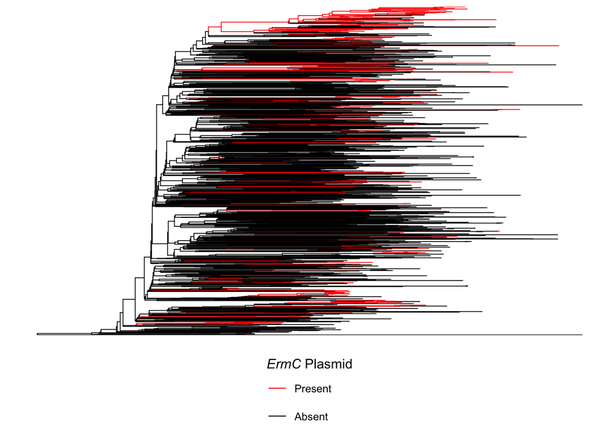

```r
custom_theme <- scale_color_manual(breaks = c(1,0), labels = c("Present","Absent"), values= c("red","black"), name = '*ErmC* Plasmid',guide = guide_legend(title.position = "top", label.position = "right",nrow=2,order=1))

get_painted_tree_with_states <- function(parent_child_df,tr){
    num_nodes <- nrow(tr$edge) + 1
    root_node <- length(tr$tip.label) + 1
    root_value <- unique(parent_child_df[parent_child_df$parent ==
        root_node, "parent_value"])
    parent_child_df <- parent_child_df[order(parent_child_df$child,
        decreasing = FALSE), ]
    number_tips <- length(tr$tip.label)
    outcome_str <- parent_child_df[parent_child_df$child <= number_tips,
        "child_value"]
    parent_str <- parent_child_df[parent_child_df$child > number_tips,
        "child_value"]
    state_df <- data.frame(node = seq_len(num_nodes), state = c(outcome_str,
        root_value, parent_str))
    tr <- full_join(tr, state_df)
    painted_tree <- ggtree(tr, mapping = aes(color = as.factor(state)),size=0.3) +
        custom_theme
    return(painted_tree)
}

p1 <- get_painted_tree_with_states(ermC_asr$parent_child_df,tr = tr_midpoint) + custom_theme + theme(legend.position = 'bottom',legend.title = ggtext::element_markdown())

p1
```

## Painted phylogeny with clustering data

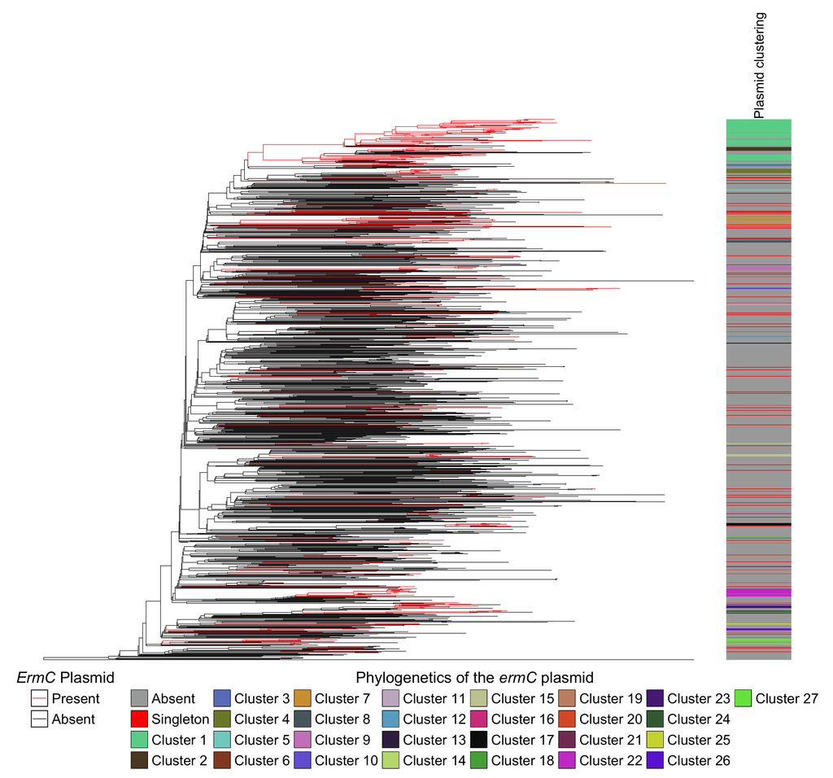

```r
# Theme
consistent_theme <- theme(legend.position = 'bottom',legend.direction="horizontal", legend.justification = "center", legend.key = element_rect(colour = c('black')),legend.box.spacing = unit(.0001, "cm"),legend.key.size = unit(.75, "cm"),legend.key.width = unit(.75, "cm"),legend.spacing.x=unit(.75, "cm"), legend.title = ggtext::element_markdown(size=20,hjust=0.5),legend.text = element_text(size=18,hjust=0),legend.spacing = unit(0,'cm'),legend.margin = margin(t=-1,b=0.25,unit='cm'))

# Add new scale fill
p1.1 <- p1 + ggnewscale::new_scale_fill()

# Add matrix with cluster calls
A <- gheatmap(p1.1, ermC_asr_cluster %>% select(asr_cluster_renamed)  %>% `colnames<-`("Plasmid clustering") %>% mutate_all(as.factor) , colnames_position = "top",colnames_angle=90, colnames_offset_y = 0.25, hjust = 0, color = NA, font.size = 6, width = .1,offset =0) + cluster_scale + ylim(NA,1250) + theme(legend.position = 'bottom') + consistent_theme

A
```

# Figure B - Histogram with clustering over time

## Themes

```r
format <- theme(legend.position = "bottom",
                  axis.text =   element_text(size=18, color="black"),
                  axis.title = element_text(size = 20, color="black"),
                  axis.ticks.length = unit(0.25, "cm"),
                  legend.text =   element_text(size=18, color="black"),
                  legend.title = element_text(size = 20, color="black")
)

theme_bw_me <- theme(panel.background = element_rect(fill = "white",colour = NA), panel.grid = element_blank(),
                     strip.background = element_rect(fill = "white",colour = "black"),
                     panel.grid.major = element_blank(),
                     panel.grid.minor = element_blank(),
                     axis.line = element_line(colour = "black"),legend.position = "bottom")
```

## Add clustering data to metadata

```r
df <- left_join(df,ermC_asr_cluster %>% mutate(seq_id = tip_name))

cluster_levels <- c(paste0("Cluster ",ncluster:1),"Singleton","No feature")

df$asr_cluster_renamed_rev <- factor(df$asr_cluster_renamed, levels = cluster_levels,labels = gsub("No feature","Absent",cluster_levels))
```

## Histogram

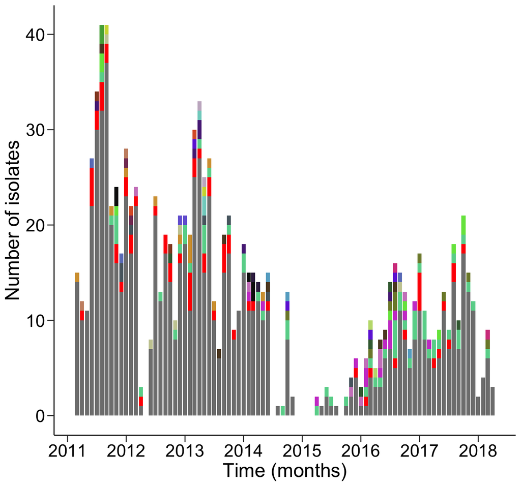

```r
x_year_scale <-scale_x_date(date_breaks = "1 year",date_labels = "%Y")

B <- ggplot(data = df, aes(x = date_bin, fill = fct_rev(fct_infreq(asr_cluster_renamed_rev)))) + geom_histogram(stat  = 'count') + format + theme_bw_me + theme(legend.position='none')  + xlab("Time (months)") + ylab("Number of isolates") +  cluster_scale + x_year_scale

B
```

# Figure C - Duration of clusters in sample collection

## Cluster isolate, patient, statistics statistics

```r
groups <- c("Absent","Singleton",names(clusters_col))

get_cluster_stats <- function(group){
  df_sub <- df %>% subset(asr_cluster_renamed_rev == group)
  n_isolates <- as.numeric(nrow(df_sub))
  n_patients <- as.numeric(length(unique(df_sub$patient_id)))
  subsequent_transmission <- as.numeric(n_patients - 1)

  sum <- as.data.frame(summary(df_sub$date)) %>% t %>% as.data.frame %>% `colnames<-`(snakecase::to_snake_case(colnames(.))) %>% mutate_all(lubridate::as_date)
  sum$duration <- sum$max - sum$min
  cbind(group,n_isolates,n_patients,subsequent_transmission,sum) %>% `rownames<-`(NULL)
}

cluster_individual_data <- lapply(groups,get_cluster_stats) %>% do.call(rbind.data.frame,.)

cluster_individual_data %>% favorite_kable()
```

| group | n_isolates | n_patients | subsequent_transmission | min | 1_st_qu | median | mean | 3_rd_qu | max | duration |
| --- | --- | --- | --- | --- | --- | --- | --- | --- | --- | --- |
| Absent | 835 | 730 | 729 | 2011-03-09 | 2012-01-03 | 2013-04-02 | 2013-10-26 | 2014-10-26 | 2018-04-12 | 2591 days |
| Singleton | 64 | 63 | 62 | 2011-04-28 | 2012-01-23 | 2013-03-02 | 2013-10-06 | 2014-11-01 | 2017-10-05 | 2352 days |
| Cluster 1 | 61 | 60 | 59 | 2011-08-10 | 2013-05-18 | 2016-03-25 | 2015-05-22 | 2017-01-12 | 2018-03-19 | 2413 days |
| Cluster 2 | 7 | 7 | 6 | 2011-08-06 | 2013-09-05 | 2014-06-10 | 2014-09-07 | 2016-05-26 | 2016-08-04 | 1825 days |
| Cluster 3 | 3 | 3 | 2 | 2011-06-06 | 2011-09-17 | 2011-12-29 | 2013-05-15 | 2014-05-04 | 2016-09-08 | 1921 days |
| Cluster 4 | 9 | 9 | 8 | 2014-10-26 | 2016-07-25 | 2016-08-31 | 2016-10-26 | 2017-06-13 | 2018-03-23 | 1244 days |
| Cluster 5 | 3 | 3 | 2 | 2013-04-03 | 2013-04-28 | 2013-05-23 | 2013-05-06 | 2013-05-23 | 2013-05-24 | 51 days |
| Cluster 6 | 2 | 2 | 1 | 2011-07-08 | 2011-11-04 | 2012-03-03 | 2012-03-03 | 2012-07-01 | 2012-10-29 | 479 days |
| Cluster 7 | 11 | 11 | 10 | 2011-03-19 | 2012-04-07 | 2013-02-15 | 2012-11-04 | 2013-04-16 | 2014-05-30 | 1168 days |
| Cluster 8 | 7 | 7 | 6 | 2011-12-12 | 2012-01-27 | 2013-05-08 | 2013-05-10 | 2014-02-10 | 2015-11-04 | 1423 days |
| Cluster 9 | 8 | 8 | 7 | 2012-03-11 | 2015-06-21 | 2016-01-22 | 2015-06-30 | 2016-05-18 | 2016-10-28 | 1692 days |
| Cluster 10 | 2 | 2 | 1 | 2012-12-20 | 2012-12-24 | 2012-12-28 | 2012-12-28 | 2013-01-01 | 2013-01-06 | 17 days |
| Cluster 11 | 2 | 2 | 1 | 2013-04-29 | 2013-05-01 | 2013-05-03 | 2013-05-03 | 2013-05-05 | 2013-05-08 | 9 days |
| Cluster 12 | 3 | 3 | 2 | 2014-06-16 | 2014-08-14 | 2014-10-13 | 2015-05-18 | 2015-11-02 | 2016-11-22 | 890 days |
| Cluster 13 | 2 | 2 | 1 | 2014-03-20 | 2014-03-25 | 2014-03-30 | 2014-03-30 | 2014-04-04 | 2014-04-09 | 20 days |
| Cluster 14 | 2 | 2 | 1 | 2016-03-21 | 2016-03-28 | 2016-04-04 | 2016-04-04 | 2016-04-11 | 2016-04-18 | 28 days |
| Cluster 15 | 5 | 5 | 4 | 2011-09-22 | 2012-06-24 | 2012-11-06 | 2013-05-11 | 2012-12-28 | 2016-09-30 | 1835 days |
| Cluster 16 | 2 | 2 | 1 | 2016-08-29 | 2017-01-14 | 2017-06-02 | 2017-06-02 | 2017-10-18 | 2018-03-06 | 554 days |
| Cluster 17 | 5 | 5 | 4 | 2011-11-11 | 2011-11-27 | 2014-02-15 | 2013-04-04 | 2014-03-08 | 2014-03-20 | 860 days |
| Cluster 18 | 2 | 2 | 1 | 2011-08-04 | 2011-08-10 | 2011-08-16 | 2011-08-16 | 2011-08-22 | 2011-08-28 | 24 days |
| Cluster 19 | 2 | 2 | 1 | 2011-04-03 | 2011-06-11 | 2011-08-19 | 2011-08-19 | 2011-10-27 | 2012-01-04 | 276 days |
| Cluster 20 | 2 | 2 | 1 | 2012-02-15 | 2012-05-22 | 2012-08-28 | 2012-08-28 | 2012-12-03 | 2013-03-11 | 390 days |
| Cluster 21 | 2 | 2 | 1 | 2012-01-31 | 2012-01-31 | 2012-02-01 | 2012-02-01 | 2012-02-01 | 2012-02-02 | 2 days |
| Cluster 22 | 15 | 14 | 13 | 2014-02-18 | 2016-01-03 | 2016-06-30 | 2016-02-16 | 2016-08-03 | 2017-03-19 | 1125 days |
| Cluster 23 | 6 | 6 | 5 | 2011-07-20 | 2013-03-14 | 2013-04-01 | 2013-08-21 | 2013-10-30 | 2016-07-28 | 1835 days |
| Cluster 24 | 5 | 5 | 4 | 2012-10-30 | 2016-01-11 | 2016-03-22 | 2015-11-16 | 2016-07-29 | 2017-09-19 | 1785 days |
| Cluster 25 | 2 | 2 | 1 | 2011-09-04 | 2012-02-09 | 2012-07-16 | 2012-07-16 | 2012-12-21 | 2013-05-29 | 633 days |
| Cluster 26 | 4 | 4 | 3 | 2013-03-03 | 2014-05-30 | 2015-07-04 | 2015-03-12 | 2016-04-15 | 2016-08-04 | 1250 days |
| Cluster 27 | 9 | 9 | 8 | 2011-08-25 | 2011-11-17 | 2016-10-31 | 2015-06-13 | 2017-08-04 | 2017-10-11 | 2239 days |

```r
write_csv(cluster_individual_data,"./thiede_steinberg_et_al_MRSA_ermC/data/phylogenetic_analysis/ermC_ASR_cluster_individual_data.csv")
```

## Differences in subsequent transmission events across clusters (i.e., n_patients - 1)

```r
cluster_only_individual_stats <- subset(cluster_individual_data,!group %in% c("Absent","Singleton"))

summary(cluster_only_individual_stats$subsequent_transmission)
```

```
   Min. 1st Qu.  Median    Mean 3rd Qu.    Max.
  1.000   1.000   2.000   5.704   6.000  59.000
```

## Cluster duration differences

```r
summary(cluster_only_individual_stats$duration)
```

```
Time differences in days
   Min. 1st Qu.  Median    Mean 3rd Qu.    Max.
    2.0   163.5   890.0   962.5  1738.5  2413.0
```

## Cluster duration boxplot

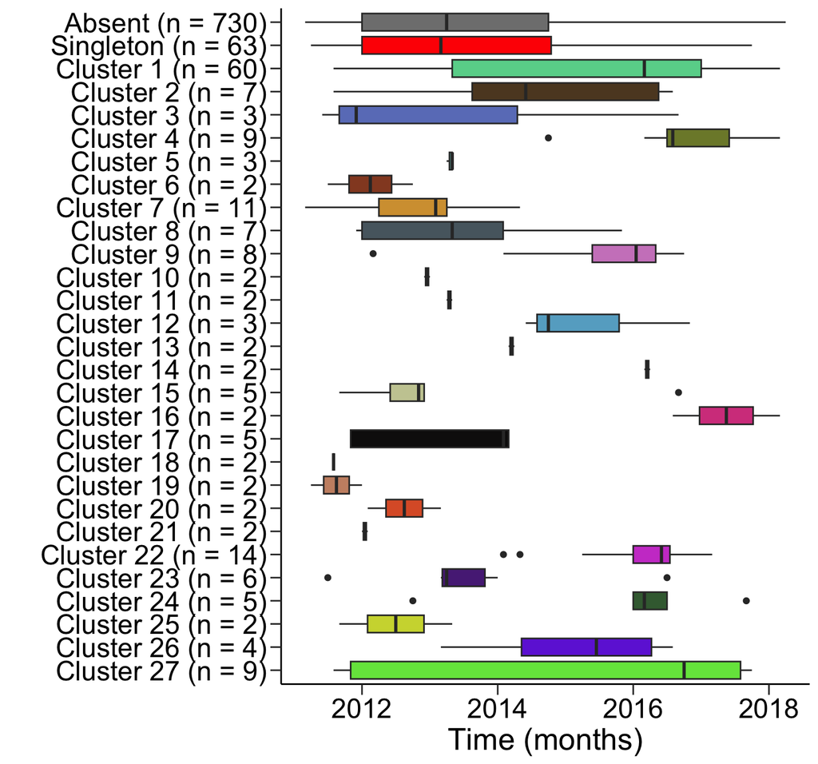

```r
# Edit y-axis
groups <- levels(df$asr_cluster_renamed_rev)
cluster_number_name <- sapply(groups,FUN=function(group_name,cluster_individual_data){
  stats_sub <- subset(cluster_individual_data,group == group_name)
  n_patients <- stats_sub[["n_patients"]]
  paste0(group_name," (n = ",n_patients,")")
},cluster_individual_data = cluster_individual_data) %>% `names<-`(groups)

# Recode y axis labels using cluster_number_name
recoded_y_scale <-  scale_y_discrete(labels = cluster_number_name)

# Cluster duration in study
C <- ggplot(data = df, aes(x = date_bin, y = asr_cluster_renamed_rev, fill = asr_cluster_renamed_rev))  + format + geom_boxplot() + theme_bw_me  + theme(legend.position='none') + xlab("Time (months)") + ylab("")+  cluster_scale + recoded_y_scale

C
```

# Supplemental figure: Frequent emergence and spread of ermC plasmid-containing strains

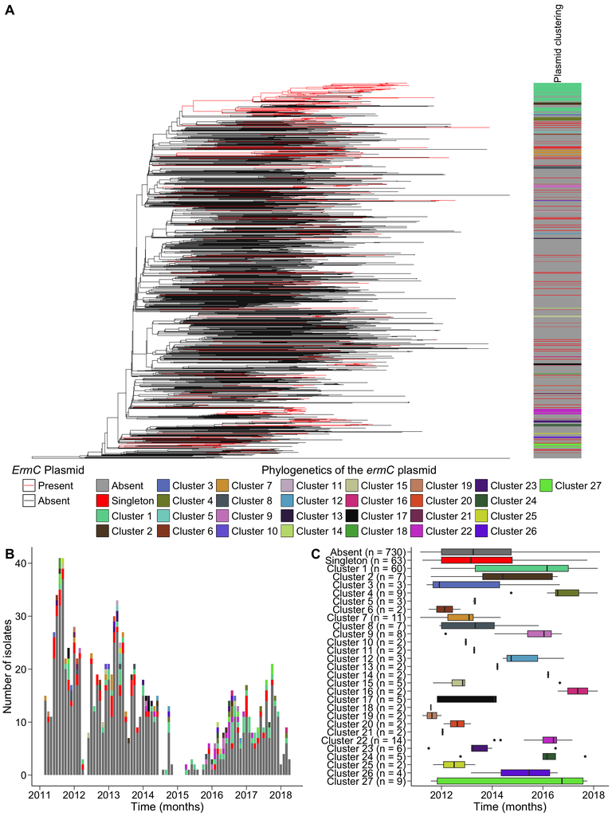

```r
cow_A <- cowplot::plot_grid(A,labels="A",label_size=24)
cow_BC <- cowplot::plot_grid(B,C,ncol=2,labels=c("B","C"),label_size = 24)

final_figure <- cowplot::plot_grid(cow_A,cow_BC,ncol=1,labels = c("",""),rel_heights = c(1,0.50))

final_figure
```

```r
ggsave("./thiede_steinberg_et_al_MRSA_ermC/figures/s_figure_ermC_asr_clustering.png",plot = final_figure, dpi = 900, width = 15, height = 20,bg='white')
```